# Join DT Tables, Similar to DB Tables

SunnyBingoMe

2016-06-29

# Prepare Data

```r
library(dplyr)
library(readr)
library(data.table)
hero = "
name,       alignment, gender,   publisher
Magneto,    bad,       male,     MarvelDuplicate
Storm,      good,      female,   MarvelDuplicate
Batman,     good,      male,     DC
Joker,      bad,       male,     DC
Catwoman,   bad,       female,   DC
Hellboy,    good,      male,     Dark Horse Comics
"
hero = read_csv(hero, trim_ws = TRUE, skip = 1)
hero = data.table(hero)

publisher = "
publisher,   yr_founded
DC,              1934
MarvelDuplicate, 1939
MarvelDuplicate, 8888
Image,           1992
"
publisher = read_csv(publisher, trim_ws = TRUE, skip = 1)
publisher = data.table(publisher)
```

**For all the `join` commands, if a key is set for both dt, then `on = 'key_col_name'` can be elided.**

WARN: row orders are not guaranteed

# Left-Join & Inner-Join

**by default, nomatch cells := NA**

```r
hero[publisher, on = "publisher"]
```

| name | alignment | gender | publisher | yr_founded |
| --- | --- | --- | --- | --- |
| Batman | good | male | DC | 1934 |
| Joker | bad | male | DC | 1934 |
| Catwoman | bad | female | DC | 1934 |
| Magneto | bad | male | MarvelDuplicate | 1939 |
| Storm | good | female | MarvelDuplicate | 1939 |
| Magneto | bad | male | MarvelDuplicate | 8888 |
| Storm | good | female | MarvelDuplicate | 8888 |
| NA | NA | NA | Image | 1992 |

**nomatch = 0 means delete no-matched rows** (becomes inner-join)

```r
hero[publisher, nomatch = 0, on = "publisher"]
```

| name | alignment | gender | publisher | yr_founded |
| --- | --- | --- | --- | --- |
| Batman | good | male | DC | 1934 |
| Joker | bad | male | DC | 1934 |
| Catwoman | bad | female | DC | 1934 |
| Magneto | bad | male | MarvelDuplicate | 1939 |
| Storm | good | female | MarvelDuplicate | 1939 |
| Magneto | bad | male | MarvelDuplicate | 8888 |
| Storm | good | female | MarvelDuplicate | 8888 |

# Right-Join & Inner, all = TRUE

right-join will keep all right-side table rows, unfortunately, we have to **swap two data.table’s** to make a right-join (using left-join format)

```r
publisher[hero, on = "publisher"]
```

| publisher | yr_founded | name | alignment | gender |
| --- | --- | --- | --- | --- |
| MarvelDuplicate | 1939 | Magneto | bad | male |
| MarvelDuplicate | 8888 | Magneto | bad | male |
| MarvelDuplicate | 1939 | Storm | good | female |
| MarvelDuplicate | 8888 | Storm | good | female |
| DC | 1934 | Batman | good | male |
| DC | 1934 | Joker | bad | male |
| DC | 1934 | Catwoman | bad | female |
| Dark Horse Comics | NA | Hellboy | good | male |

# Outer-/Full-Join & Inner-Join

Outer-(or full-) join will keep both tables content, with extra NA’s

we need function `merge`; **param is `by = 'key_name'`, NOT `on`.**

```r
merge(hero, publisher, by = "publisher", all = TRUE)
```

| publisher | name | alignment | gender | yr_founded |
| --- | --- | --- | --- | --- |
| DC | Batman | good | male | 1934 |
| DC | Joker | bad | male | 1934 |
| DC | Catwoman | bad | female | 1934 |
| Dark Horse Comics | Hellboy | good | male | NA |
| Image | NA | NA | NA | 1992 |
| MarvelDuplicate | Magneto | bad | male | 1939 |
| MarvelDuplicate | Magneto | bad | male | 8888 |
| MarvelDuplicate | Storm | good | female | 1939 |
| MarvelDuplicate | Storm | good | female | 8888 |

if not `all` content is kept, it becomes inner-join, again.

```r
merge(hero, publisher, by = "publisher")
```

| publisher | name | alignment | gender | yr_founded |
| --- | --- | --- | --- | --- |
| DC | Batman | good | male | 1934 |
| DC | Joker | bad | male | 1934 |
| DC | Catwoman | bad | female | 1934 |
| MarvelDuplicate | Magneto | bad | male | 1939 |
| MarvelDuplicate | Magneto | bad | male | 8888 |
| MarvelDuplicate | Storm | good | female | 1939 |
| MarvelDuplicate | Storm | good | female | 8888 |

# Anti-Join

Give the rows that only exist on left-table

```r
hero[!publisher, on = "publisher"]
```

| name | alignment | gender | publisher |
| --- | --- | --- | --- |
| Hellboy | good | male | Dark Horse Comics |

```r
publisher[!hero, on = "publisher"]
```

| publisher | yr_founded |
| --- | --- |
| Image | 1992 |

# Cross-Join

Give the multiplied rows like matrix-multiplication.

`nrow(new_table) := nrow(left_table) * nrow(right_table)`

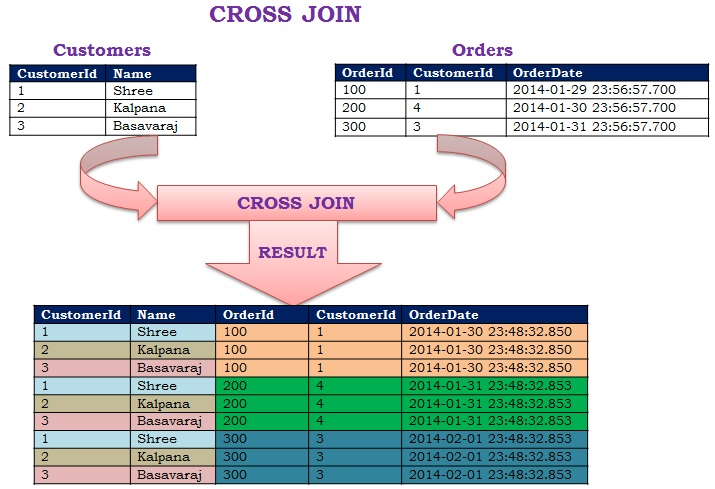

cross join

[ref](http://sqlhints.com/tag/cross-join/)

# Semi-Join (Only Keep Half Side Content)

```r
index = unique(hero[publisher, on = "publisher", which=TRUE, allow.cartesian=TRUE])
hero[index]
```

| name | alignment | gender | publisher |
| --- | --- | --- | --- |
| Batman | good | male | DC |
| Joker | bad | male | DC |
| Catwoman | bad | female | DC |
| Magneto | bad | male | MarvelDuplicate |
| Storm | good | female | MarvelDuplicate |
| NA | NA | NA | NA |

you can add `nomatch = 0`

# Self-Join

Self-join has [not been implemented for DT yet](http://stackoverflow.com/questions/14983805/how-to-self-join-a-data-table-on-a-condition). A `for loop` or some other methods are necessary.

See self-join definition [here](http://sqlhints.com/tag/cross-join/).

See examples & solutions for DT [here](http://stackoverflow.com/questions/3362038/what-is-self-join-and-when-would-you-use-it)

ref:

[data source](http://stat545.com/bit001_dplyr-cheatsheet.html), which is modified here.

[semi-Join](http://stackoverflow.com/questions/18969420/perform-a-semi-join-with-data-table)

[SQL Join, chart explained](http://stackoverflow.com/questions/5706437/whats-the-difference-between-inner-join-left-join-right-join-and-full-join)

[output not shown]

```
## Session info--------------------------------------------------------------
```

```
##  setting  value
##  version  R version 3.1.1 (2014-07-10)
##  system   x86_64, mingw32
##  ui       RTerm
##  language (EN)
##  collate  English_United Kingdom.1252
##  tz       Africa/Cairo
```

```
## Packages------------------------------------------------------------------
```

```
##  package    * version date       source
##  assertthat   0.1     2013-12-06 CRAN (R 3.1.1)
##  chron        2.3.47  2015-06-24 CRAN (R 3.1.3)
##  data.table * 1.9.6   2015-09-19 CRAN (R 3.1.3)
##  DBI          0.3.1   2014-09-24 CRAN (R 3.1.1)
##  devtools     1.6.1   2014-10-07 CRAN (R 3.1.2)
##  digest       0.6.4   2013-12-03 CRAN (R 3.1.1)
##  dplyr      * 0.3.0.2 2014-10-11 CRAN (R 3.1.1)
##  evaluate     0.9     2016-04-29 CRAN (R 3.1.3)
##  formatR      1.3     2016-03-05 CRAN (R 3.1.3)
##  highr        0.3     2013-10-26 CRAN (R 3.1.1)
##  htmltools    0.3.5   2016-03-21 CRAN (R 3.1.3)
##  knitr        1.13    2016-05-09 CRAN (R 3.1.1)
##  magrittr     1.0.1   2014-05-15 CRAN (R 3.1.2)
##  Rcpp         0.12.4  2016-03-26 CRAN (R 3.1.3)
##  readr      * 0.2.2   2015-10-22 CRAN (R 3.1.3)
##  rmarkdown    0.9.6   2016-05-01 CRAN (R 3.1.1)
##  rstudioapi   0.5     2016-01-24 CRAN (R 3.1.3)
##  stringi      0.5.5   2015-06-29 CRAN (R 3.1.3)
##  stringr      1.0.0   2015-04-30 CRAN (R 3.1.3)
##  yaml         2.1.13  2014-06-12 CRAN (R 3.1.1)
```